# Bird phenology exploration

Michael W Belitz

2023-03-07

## What is the response of fledge dates to GDD deviation?

```r
tm_fledge <- lmer(juv_meanday ~ spring.dev + mean_ffp +
                   PC1 +
                   spring.dev:mean_ffp +
                   spring.dev:PC1 +
                   (1|station) + (1|sci_name),
                 data = fledge_scaled, na.action = na.fail, REML = F)

summary(tm_fledge)
```

```
## Linear mixed model fit by maximum likelihood . t-tests use Satterthwaite's
##   method [lmerModLmerTest]
## Formula: juv_meanday ~ spring.dev + mean_ffp + PC1 + spring.dev:mean_ffp +
##     spring.dev:PC1 + (1 | station) + (1 | sci_name)
##    Data: fledge_scaled
##
##      AIC      BIC   logLik deviance df.resid
##  14300.4  14351.3  -7141.2  14282.4     2097
##
## Scaled residuals:
##     Min      1Q  Median      3Q     Max
## -4.6162 -0.5827  0.0466  0.6176  3.2667
##
## Random effects:
##  Groups   Name        Variance Std.Dev.
##  station  (Intercept) 12.26    3.502
##  sci_name (Intercept) 21.03    4.585
##  Residual             44.17    6.646
## Number of obs: 2106, groups:  station, 256; sci_name, 34
##
## Fixed effects:
##                      Estimate Std. Error        df t value Pr(>|t|)
## (Intercept)          198.9937     0.8928   40.0630 222.884  < 2e-16 ***
## spring.dev            -0.5909     0.1545 2031.7985  -3.824 0.000135 ***
## mean_ffp              -5.2575     0.3968  200.7885 -13.248  < 2e-16 ***
## PC1                    1.9708     0.6841   35.6377   2.881 0.006676 **
## spring.dev:mean_ffp   -0.6416     0.1887 1956.2058  -3.400 0.000687 ***
## spring.dev:PC1        -0.3842     0.1696 1979.8273  -2.265 0.023590 *
## ---
## Signif. codes:  0 '***' 0.001 '**' 0.01 '*' 0.05 '.' 0.1 ' ' 1
##
## Correlation of Fixed Effects:
##             (Intr) sprng. mn_ffp PC1    spr.:_
## spring.dev  -0.007
## mean_ffp     0.012  0.028
## PC1          0.178  0.002  0.093
## sprng.dv:m_  0.012 -0.002 -0.026  0.017
## sprng.d:PC1  0.007  0.083  0.024 -0.001  0.404
```

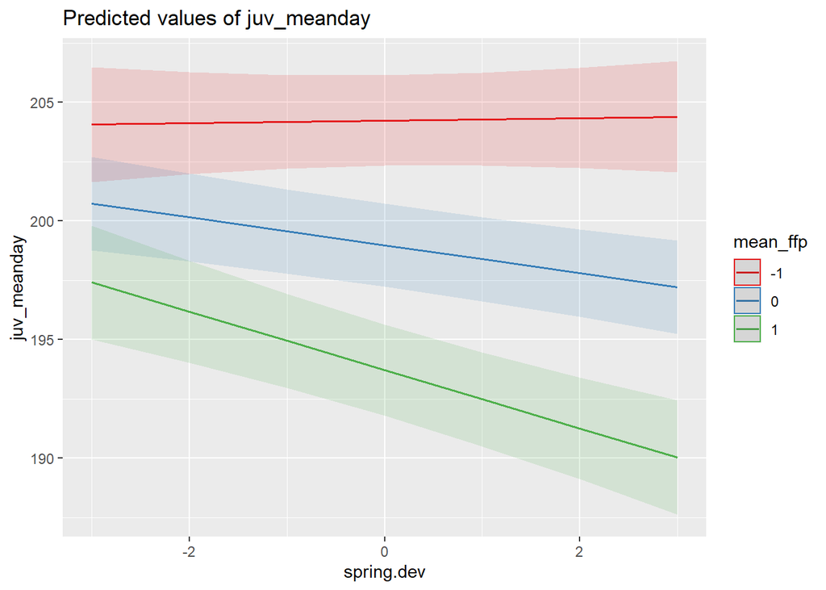

```r
plot_model(tm_fledge, type = "eff", terms = c("spring.dev", "mean_ffp"))
```

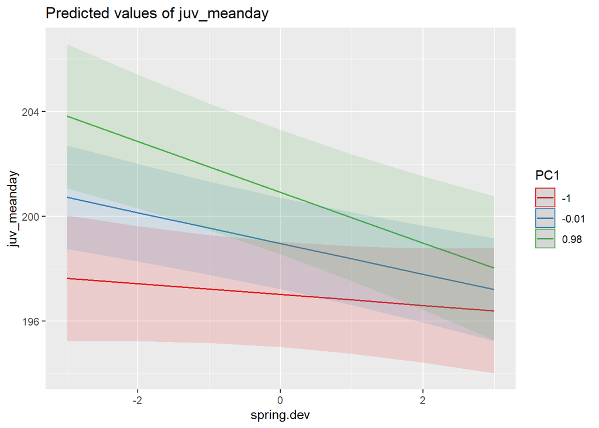

```r
plot_model(tm_fledge, type = "eff", terms = c("spring.dev", "PC1"))
```

## What is the response of fledge dates to Greenup deviation?

```r
tm_fledge2 <- lmer(juv_meanday ~ greenup.dev + mean_ffp.x +
                   PC1 +
                   greenup.dev:mean_ffp.x +
                   greenup.dev:PC1 +
                   (1|station) + (1|sci_name),
                 data = fledge_scaled_greenup, na.action = na.fail, REML = F)

summary(tm_fledge2)
```

```
## Linear mixed model fit by maximum likelihood . t-tests use Satterthwaite's
##   method [lmerModLmerTest]
## Formula:
## juv_meanday ~ greenup.dev + mean_ffp.x + PC1 + greenup.dev:mean_ffp.x +
##     greenup.dev:PC1 + (1 | station) + (1 | sci_name)
##    Data: fledge_scaled_greenup
##
##      AIC      BIC   logLik deviance df.resid
##  11346.8  11395.6  -5664.4  11328.8     1677
##
## Scaled residuals:
##     Min      1Q  Median      3Q     Max
## -4.2590 -0.5876  0.0512  0.6129  3.3165
##
## Random effects:
##  Groups   Name        Variance Std.Dev.
##  station  (Intercept) 11.39    3.375
##  sci_name (Intercept) 21.10    4.594
##  Residual             41.43    6.436
## Number of obs: 1686, groups:  station, 181; sci_name, 34
##
## Fixed effects:
##                         Estimate Std. Error        df t value Pr(>|t|)
## (Intercept)             198.7942     0.9192   40.9089 216.278  < 2e-16 ***
## greenup.dev               0.7288     0.1671 1593.5524   4.361 1.38e-05 ***
## mean_ffp.x               -5.5318     0.4588  135.3559 -12.056  < 2e-16 ***
## PC1                       2.1335     0.7166   37.1452   2.977   0.0051 **
## greenup.dev:mean_ffp.x    0.4134     0.1832 1525.6470   2.257   0.0241 *
## greenup.dev:PC1           0.1039     0.2103 1577.7887   0.494   0.6212
## ---
## Signif. codes:  0 '***' 0.001 '**' 0.01 '*' 0.05 '.' 0.1 ' ' 1
##
## Correlation of Fixed Effects:
##             (Intr) grnp.d mn_ff. PC1    gr.:_.
## greenup.dev -0.001
## mean_ffp.x   0.045  0.012
## PC1          0.139  0.005  0.085
## grnp.dv:m_.  0.009 -0.123  0.037 -0.018
## grnp.dv:PC1  0.012  0.013  0.053 -0.024  0.537
```

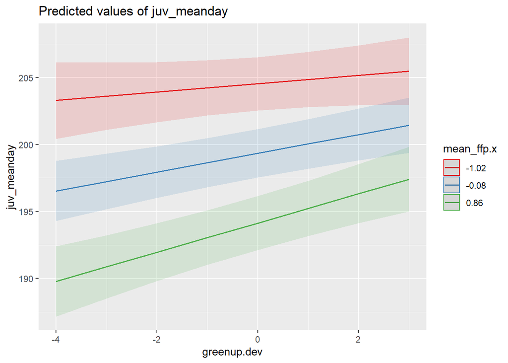

```r
plot_model(tm_fledge2, type = "eff", terms = c("greenup.dev", "mean_ffp.x"))
```

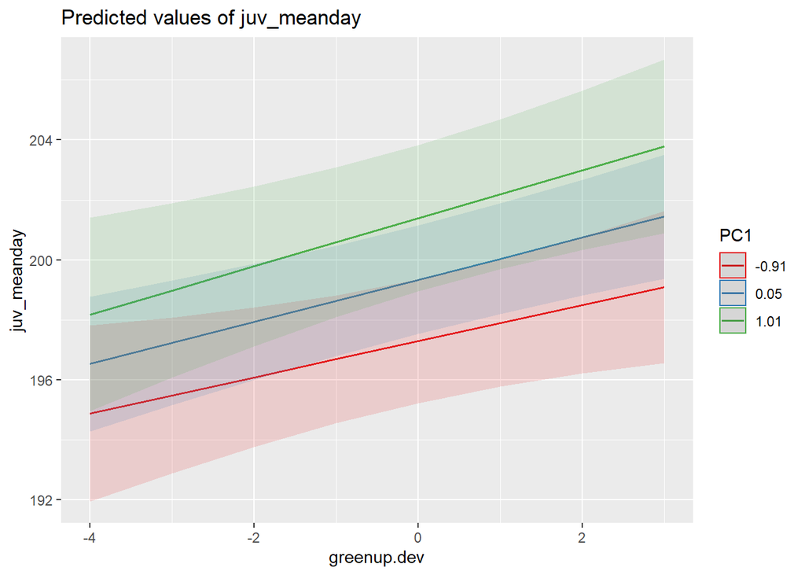

```r
plot_model(tm_fledge2, type = "eff", terms = c("greenup.dev", "PC1"))
```

## Arrival model

Let’s check what arrival looks like given my modeling framework. This should co-align with Youngflesh et al., 2021. It does.

```r
tm_arr <- lmer(arr_GAM_mean ~ spring.dev + mean_ffp +
                   PC1 +
                   spring.dev:mean_ffp +
                   spring.dev:PC1 +
                   (1|cell) + (1|species),
                 data = arr_gdd_scaled, na.action = na.fail, REML = F)

summary(tm_arr)
```

```
## Linear mixed model fit by maximum likelihood . t-tests use Satterthwaite's
##   method [lmerModLmerTest]
## Formula: arr_GAM_mean ~ spring.dev + mean_ffp + PC1 + spring.dev:mean_ffp +
##     spring.dev:PC1 + (1 | cell) + (1 | species)
##    Data: arr_gdd_scaled
##
##      AIC      BIC   logLik deviance df.resid
## 129557.6 129629.0 -64769.8 129539.6    20567
##
## Scaled residuals:
##      Min       1Q   Median       3Q      Max
## -14.9450  -0.5663  -0.0124   0.5557   6.4277
##
## Random effects:
##  Groups   Name        Variance Std.Dev.
##  cell     (Intercept) 27.30    5.225
##  species  (Intercept) 40.78    6.386
##  Residual             30.68    5.539
## Number of obs: 20576, groups:  cell, 73; species, 56
##
## Fixed effects:
##                       Estimate Std. Error         df t value Pr(>|t|)
## (Intercept)          1.190e+02  1.055e+00  1.053e+02 112.846  < 2e-16 ***
## spring.dev          -4.806e-01  4.082e-02  2.045e+04 -11.776  < 2e-16 ***
## mean_ffp            -1.072e+01  4.575e-01  6.937e+01 -23.442  < 2e-16 ***
## PC1                  6.455e+00  6.317e-01  5.590e+01  10.219 2.11e-14 ***
## spring.dev:mean_ffp  2.586e-01  3.954e-02  2.045e+04   6.539 6.33e-11 ***
## spring.dev:PC1       1.741e-01  3.191e-02  2.044e+04   5.457 4.89e-08 ***
## ---
## Signif. codes:  0 '***' 0.001 '**' 0.01 '*' 0.05 '.' 0.1 ' ' 1
##
## Correlation of Fixed Effects:
##             (Intr) sprng. mn_ffp PC1    spr.:_
## spring.dev   0.001
## mean_ffp    -0.013 -0.002
## PC1          0.000  0.000  0.000
## sprng.dv:m_ -0.002 -0.291  0.003  0.000
## sprng.d:PC1  0.000 -0.050 -0.001 -0.001 -0.037
```

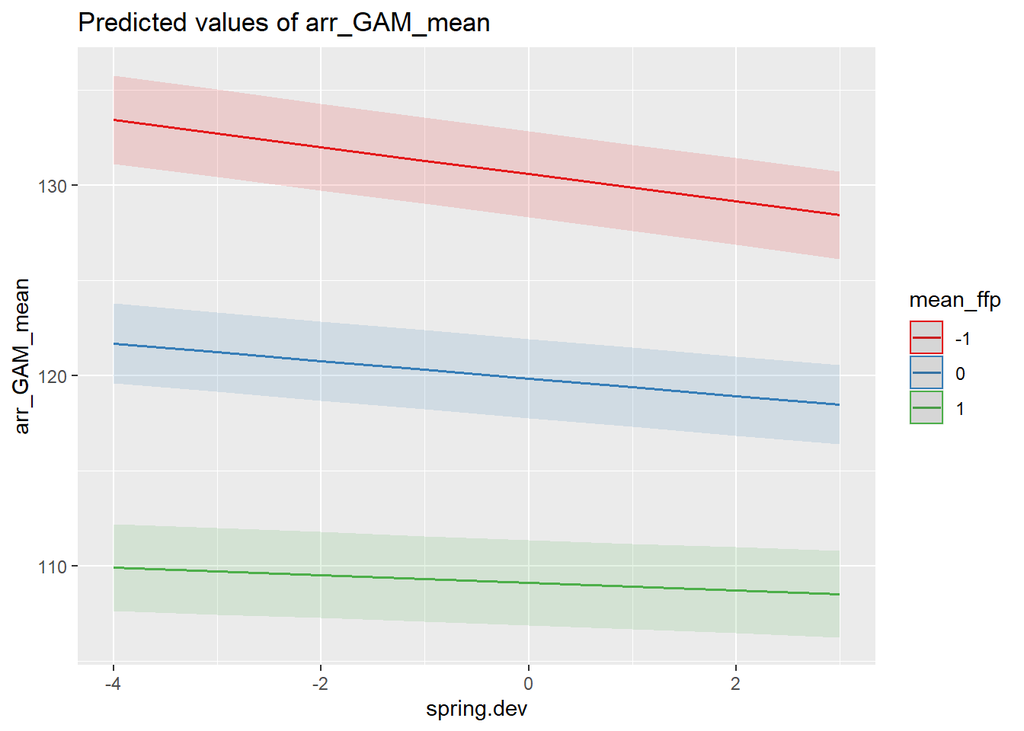

```r
plot_model(tm_arr, type = "eff", terms = c("spring.dev", "mean_ffp"))
```

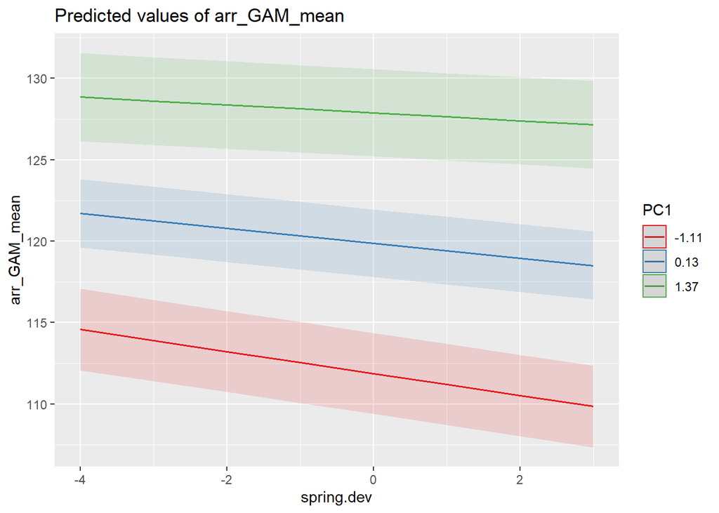

```r
plot_model(tm_arr, type = "eff", terms = c("spring.dev", "PC1"))
```

## These effects are even stronger when looking at greenup as predictor instead of GDD. We do find the same results as Youngflesh et al., 2021. So arrival is showing the same responses but fledge is doing something different.

```r
tm_arr2 <- lmer(arr_GAM_mean ~ gr_mn + mean_ffp +
                   PC1 +
                   gr_mn:mean_ffp +
                   gr_mn:PC1 +
                   (1|cell) + (1|species),
                 data = arr_gdd_scaled, na.action = na.fail, REML = F)

summary(tm_arr2)
```

```
## Linear mixed model fit by maximum likelihood . t-tests use Satterthwaite's
##   method [lmerModLmerTest]
## Formula: arr_GAM_mean ~ gr_mn + mean_ffp + PC1 + gr_mn:mean_ffp + gr_mn:PC1 +
##     (1 | cell) + (1 | species)
##    Data: arr_gdd_scaled
##
##      AIC      BIC   logLik deviance df.resid
## 127231.6 127303.0 -63606.8 127213.6    20567
##
## Scaled residuals:
##      Min       1Q   Median       3Q      Max
## -16.3885  -0.5661  -0.0176   0.5475   7.0065
##
## Random effects:
##  Groups   Name        Variance Std.Dev.
##  cell     (Intercept) 15.41    3.926
##  species  (Intercept) 44.92    6.703
##  Residual             27.43    5.237
## Number of obs: 20576, groups:  cell, 73; species, 56
##
## Fixed effects:
##                  Estimate Std. Error         df t value Pr(>|t|)
## (Intercept)     1.179e+02  1.019e+00  8.726e+01 115.660  < 2e-16 ***
## gr_mn           2.157e+00  1.004e-01  1.789e+04  21.470  < 2e-16 ***
## mean_ffp       -9.631e+00  3.546e-01  7.145e+01 -27.156  < 2e-16 ***
## PC1             6.636e+00  6.628e-01  5.596e+01  10.012 4.41e-14 ***
## gr_mn:mean_ffp -5.844e-01  9.001e-02  1.000e+04  -6.492 8.86e-11 ***
## gr_mn:PC1      -1.588e+00  3.355e-02  2.048e+04 -47.329  < 2e-16 ***
## ---
## Signif. codes:  0 '***' 0.001 '**' 0.01 '*' 0.05 '.' 0.1 ' ' 1
##
## Correlation of Fixed Effects:
##             (Intr) gr_mn  mn_ffp PC1    gr_m:_
## gr_mn       -0.045
## mean_ffp    -0.014  0.197
## PC1          0.000 -0.001  0.000
## gr_mn:mn_ff  0.124 -0.206  0.033  0.000
## gr_mn:PC1   -0.004 -0.021  0.017 -0.006 -0.014
```

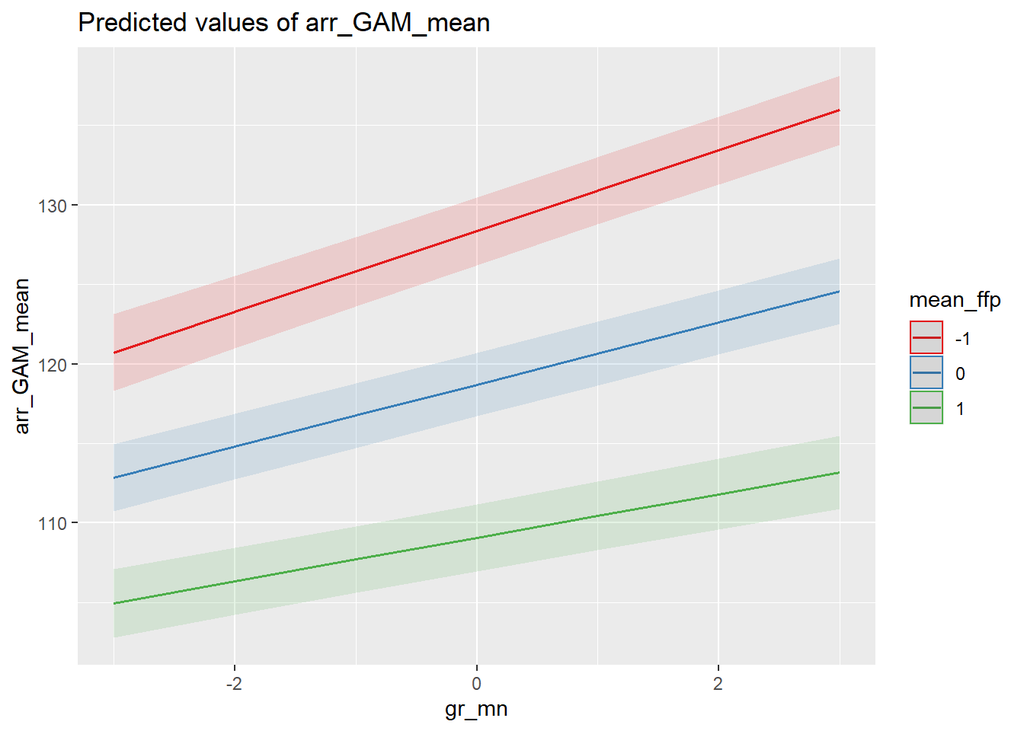

```r
plot_model(tm_arr2, type = "eff", terms = c("gr_mn", "mean_ffp"))
```

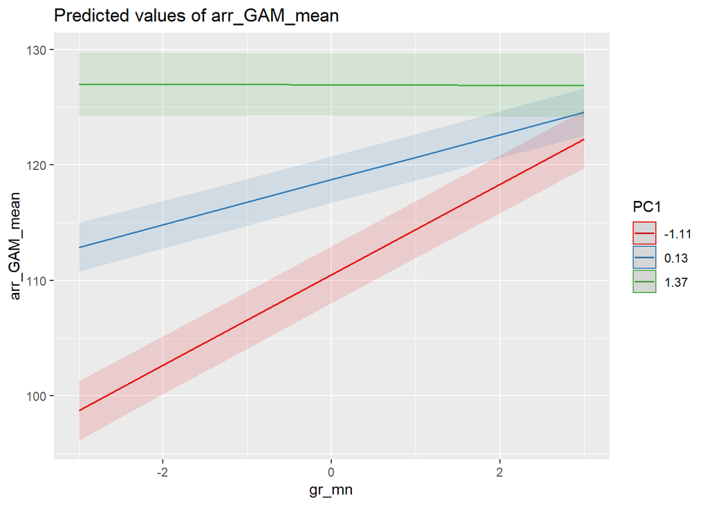

```r
plot_model(tm_arr2, type = "eff", terms = c("gr_mn", "PC1"))
```

## Where does that leave us?

1. The trait by latitude interactions for the fledge models show the opposite response than is shown in the arrival models.
2. We don’t really have evidence that green-up vs GDD interactions differ for fledge models, which we posit as a reason for the differences in-text.
3. Our results also contradict Casey’s findings in the phenology-demography manuscript currently in-review that species with lower PC1 values have fledge dates more sensitive to green-up. Why?
- I don’t know but that study occurs at a station-level and we coarsen the GDD values to a cell-level. Our study also is done at a smaller spatial area (eastern U.S. vs. continental U.S.) and thus includes fewer species.